# How has officiating of the National Basketball Association changed?

## Spring 2024 Data Science Project

Collaborators: Matthew Nashed has contributed 100%. "We, all team members, agree together that the above information is true, and we are confident about our contributions to this submitted project/final tutorial."

Matthew Nashed- May 7, 2024

I, Matthew Nashed, did everything by myself.

**Introduction**

Many people who watch basketball complain that the NBA has become “soft” because there is a surfeit of foul calls throughout the game. Social media has heightened how controversial the officiating has become in the NBA. Some people have described the NBA as unwatchable because of how many foul calls are made, lengthening the game beyond what it is supposed to be. Players now “flop” excessively in order to get a foul call, and it appears to work in the player’s favor. Flop refers to excessively acting like you were hit by an opposing player. Additionally, when a foul is not called, players will whine and complain to the referee because they are used to getting foul calls in their favor. However, on ESPN, a sports television show, former NBA player JJ Reddick stated that free throws are currently not occurring as much during NBA basketball games. I want to utilize the data provided by Basketball Reference to determine whether foul calls are now more common or in excess than they were over a decade ago. I hypothesize that the foul calls are actually not being called as often and that the type of fouls that are being called are different.

Some questions I want to answer are: Are fouls more prevalent now then over ten years ago? Are there more free throws occurring due to fouls? Are fouls resulting in more points? These questions are important to answer because they are crucial in the discussion of whether the league is softer. People cannot complain about the officiating if foul calls and free throw attempts are decreasing.

**Data Curation**

I will be utilizing data tables provided by Basketball Reference. I will be choosing 5 current National Basketball Association (NBA) referees, specifically Andy Nagy, Tre Maddox, Scott Foster, Tom Washington, and Ed Malloy, and 5 former referees from over a decade ago, such as Luis Grillo, Michael Henderson, Hue Hollins, Lee Jones, and Anthony Jordan. When you click on the name of the referees, you are sent to a page where you can extract the table of raw data of the basketball games they officiated throughout their careers. You can also extract relative data from a table provided by Basketball Reference. Source: https://www.basketball-reference.com/referees/

Below, I am transforming the data to be later used in my primary analysis

```python
import pandas as pd
pd.options.mode.chained_assignment = None  # default='warn'
import matplotlib.pyplot as plt
from sklearn import linear_model
from sklearn.model_selection import train_test_split
df = pd.read_csv("Referee_Data.csv")
df2 = df[['Season', 'PF', 'FTA', 'PTS']]
df2['Season']= [x[:4] for x in df2['Season']]
df2['Season'] = [int(x) for x in df2['Season']]
X = df2[['Season']]
Y = df2[['PF']]
X_train, X_test, Y_train, Y_test = train_test_split(X, Y, test_size=0.3)
```

**Exploratory Data Analysis**

```python
import pandas as pd
df = pd.read_csv("Referee_Data.csv")
df['Season']= [x[:4] for x in df['Season']]
print(df.head())
```

```
  Season   Lg   G    FGA   FTA    PF    PTS  FGA.1  FTA.1  PF.1  PTS.1    FG%  \
0   1994  NBA  47  161.7  55.8  48.2  202.0  160.3   55.3  47.8  200.2  0.466
1   1995  NBA  43  159.9  52.0  45.7  198.0  159.5   51.8  45.6  197.5  0.460
2   1996  NBA  61  158.3  51.0  44.5  194.4  156.7   50.5  44.0  192.4  0.456
3   1997  NBA  65  160.5  51.1  44.5  189.7  160.3   51.1  44.5  189.4  0.448
4   1998  NBA  39  158.6  50.9  42.9  182.5  156.5   50.2  42.4  180.1  0.429

     3P%    FT%
0  0.347  0.728
1  0.367  0.740
2  0.360  0.739
3  0.320  0.740
4  0.354  0.723
```

Here I have imported pandas and created a dataframe. I created an Excel file with all the combined referee data from 5 current referees Andy Nagy, Tre Maddox, Scott Foster, Tom Washington, and Ed Malloy, and 5 former referees from over a decade ago, such as Luis Grillo, Michael Henderson, Hue Hollins, Lee Jones, and Anthony Jordan. The Season column represents the NBA season that starts during that year. For example, I converted year 1994-95 to just 1994 to sort through the data more efficiently.

```python
import scipy.stats as stats
new_df = df.loc[(df['Season'] >= '2014')]
old_df = df.loc[(df['Season'] < '2014')]
print(stats.ttest_ind(new_df['PF'], old_df['PF']))
```

```
TtestResult(statistic=-11.976255111920844, pvalue=7.484713822453521e-24, df=156.0)
```

Here I am conducting a T Test on two dataframes I created. One dataframe named old_df represents how the NBA was officiated over a decade ago, which is marked by having a year that is less than 2014. The new_df dataframe represents the how the NBA is officiated in today's era, which is the decade 2014-2024. The column I decide to conduct the T Test on is the personal foul column, which represents the average number of personal fouls that are called during the game. This will help determine if there is a significant difference in between how many fouls were called over a decade ago and now. The p-value obtained from the t-test is far less than 0.05, which means that the result is statistically significant.

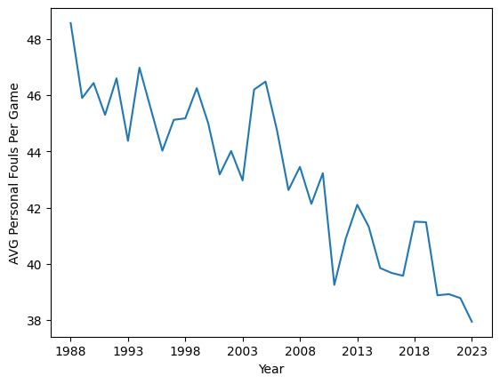

```python
import matplotlib.pyplot as plt
pd.options.mode.chained_assignment = None
df.groupby('Season')['PF'].mean().plot(ylabel='AVG Personal Fouls Per Game', xlabel = 'Year')
```

We can clearly visualize a trend in the average personal fouls being called per game through this plot. The x-axis represents the year, and the trend shows that as the years have gone, the amount of fouls called per game has gone down. This visually shows that the T-test conducted was correct in indicating that there is a statistically significant difference.

```python
import numpy as np
new_arr = new_df['FTA']
old_arr = old_df['FTA']
stats.f_oneway(new_arr, old_arr)
```

```
F_onewayResult(statistic=108.5818440646059, pvalue=1.253875869746757e-19)
```

Next, I applied the ANOVA test on the Free Throw Attempts difference between the most recent decade and the data from before 2014. Here we see the p-value once again indicates that there is a statistical significance in the difference between the two groups. Free throw attempts are an important group of analysis because it is an indicator of how many foul calls are impacting the game. Fouls lead to free throws in numerous cases, so analyzing how the new era of basketball gives out free throws is important to look at. new_arr represents the column of FTA from 2014-2024 and old_arr represents FTA before 2014

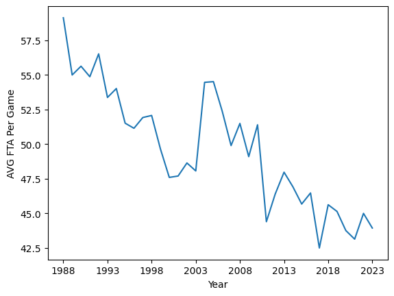

```python
df.groupby('Season')['FTA'].mean().plot(ylabel='AVG FTA Per Game', xlabel = 'Year')
```

```python
old_df.corr(method='pearson')
```

|  | G | FGA | FTA | PF | PTS | FGA.1 | FTA.1 | PF.1 | PTS.1 | FG% | 3P% | FT% |
| --- | --- | --- | --- | --- | --- | --- | --- | --- | --- | --- | --- | --- |
| G | 1.000000 | 0.115030 | -0.213315 | -0.247891 | 0.052253 | 0.141817 | -0.198826 | -0.227157 | 0.073833 | 0.058734 | 0.109422 | 0.160947 |
| FGA | 0.115030 | 1.000000 | 0.255663 | 0.073732 | 0.813859 | 0.991882 | 0.261786 | 0.083403 | 0.817631 | 0.678437 | -0.427273 | 0.299272 |
| FTA | -0.213315 | 0.255663 | 1.000000 | 0.869662 | 0.560562 | 0.258846 | 0.998352 | 0.867046 | 0.560827 | 0.510589 | -0.368828 | 0.065716 |
| PF | -0.247891 | 0.073732 | 0.869662 | 1.000000 | 0.315187 | 0.080579 | 0.867894 | 0.996669 | 0.317332 | 0.303975 | -0.300296 | -0.010378 |
| PTS | 0.052253 | 0.813859 | 0.560562 | 0.315187 | 1.000000 | 0.802736 | 0.561060 | 0.317373 | 0.995347 | 0.928573 | -0.227398 | 0.410442 |
| FGA.1 | 0.141817 | 0.991882 | 0.258846 | 0.080579 | 0.802736 | 1.000000 | 0.271967 | 0.100166 | 0.818662 | 0.681536 | -0.416450 | 0.299094 |
| FTA.1 | -0.198826 | 0.261786 | 0.998352 | 0.867894 | 0.561060 | 0.271967 | 1.000000 | 0.869797 | 0.566730 | 0.516157 | -0.367089 | 0.067888 |
| PF.1 | -0.227157 | 0.083403 | 0.867046 | 0.996669 | 0.317373 | 0.100166 | 0.869797 | 1.000000 | 0.327156 | 0.313307 | -0.296587 | -0.005812 |
| PTS.1 | 0.073833 | 0.817631 | 0.560827 | 0.317332 | 0.995347 | 0.818662 | 0.566730 | 0.327156 | 1.000000 | 0.932808 | -0.224822 | 0.410038 |
| FG% | 0.058734 | 0.678437 | 0.510589 | 0.303975 | 0.928573 | 0.681536 | 0.516157 | 0.313307 | 0.932808 | 1.000000 | -0.136461 | 0.310556 |
| 3P% | 0.109422 | -0.427273 | -0.368828 | -0.300296 | -0.227398 | -0.416450 | -0.367089 | -0.296587 | -0.224822 | -0.136461 | 1.000000 | 0.059488 |
| FT% | 0.160947 | 0.299272 | 0.065716 | -0.010378 | 0.410442 | 0.299094 | 0.067888 | -0.005812 | 0.410038 | 0.310556 | 0.059488 | 1.000000 |

```python
new_df.corr(method='pearson')
```

|  | G | FGA | FTA | PF | PTS | FGA.1 | FTA.1 | PF.1 | PTS.1 | FG% | 3P% | FT% |
| --- | --- | --- | --- | --- | --- | --- | --- | --- | --- | --- | --- | --- |
| G | 1.000000 | -0.538293 | 0.400192 | 0.379833 | -0.548446 | -0.555306 | 0.387588 | 0.379490 | -0.546138 | -0.417916 | -0.342463 | -0.557855 |
| FGA | -0.538293 | 1.000000 | -0.332258 | -0.197908 | 0.852843 | 0.968729 | -0.338158 | -0.210516 | 0.820031 | 0.481285 | 0.250699 | 0.689785 |
| FTA | 0.400192 | -0.332258 | 1.000000 | 0.674378 | -0.200086 | -0.362403 | 0.992688 | 0.676693 | -0.210887 | -0.202760 | -0.242809 | -0.087385 |
| PF | 0.379833 | -0.197908 | 0.674378 | 1.000000 | -0.239271 | -0.272127 | 0.649546 | 0.991048 | -0.269061 | -0.323840 | -0.260484 | -0.229090 |
| PTS | -0.548446 | 0.852843 | -0.200086 | -0.239271 | 1.000000 | 0.886130 | -0.175943 | -0.221368 | 0.993053 | 0.839033 | 0.520511 | 0.768516 |
| FGA.1 | -0.555306 | 0.968729 | -0.362403 | -0.272127 | 0.886130 | 1.000000 | -0.338769 | -0.252726 | 0.882203 | 0.571790 | 0.299825 | 0.702389 |
| FTA.1 | 0.387588 | -0.338158 | 0.992688 | 0.649546 | -0.175943 | -0.338769 | 1.000000 | 0.667432 | -0.173247 | -0.156373 | -0.217092 | -0.073316 |
| PF.1 | 0.379490 | -0.210516 | 0.676693 | 0.991048 | -0.221368 | -0.252726 | 0.667432 | 1.000000 | -0.236358 | -0.283719 | -0.239687 | -0.222355 |
| PTS.1 | -0.546138 | 0.820031 | -0.210887 | -0.269061 | 0.993053 | 0.882203 | -0.173247 | -0.236358 | 1.000000 | 0.861843 | 0.531470 | 0.756350 |
| FG% | -0.417916 | 0.481285 | -0.202760 | -0.323840 | 0.839033 | 0.571790 | -0.156373 | -0.283719 | 0.861843 | 1.000000 | 0.696325 | 0.523052 |
| 3P% | -0.342463 | 0.250699 | -0.242809 | -0.260484 | 0.520511 | 0.299825 | -0.217092 | -0.239687 | 0.531470 | 0.696325 | 1.000000 | 0.264167 |
| FT% | -0.557855 | 0.689785 | -0.087385 | -0.229090 | 0.768516 | 0.702389 | -0.073316 | -0.222355 | 0.756350 | 0.523052 | 0.264167 | 1.000000 |

Now what is interesting is that after 2014, the correlation between free throw attempts and points now has a WEAK negative correlation. It seems reasonable to conclude that free throws are having less of an impact on the outcome of games because of this negative correlation. Next, I will not graph the correlations so we can visualize the difference.

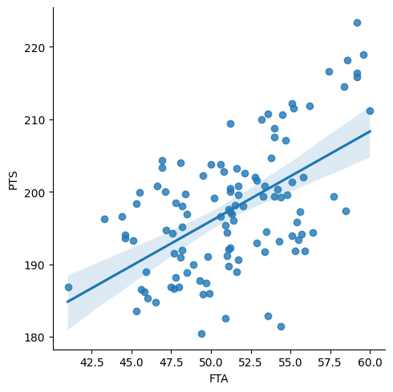

```python
import seaborn as sns
sns.lmplot(x="FTA", y="PTS", data=old_df)
```

This graph now allows us to see the correlation between more FTA and Points per 48 minutes. Now I will show the negative correlation for 2014-2024.

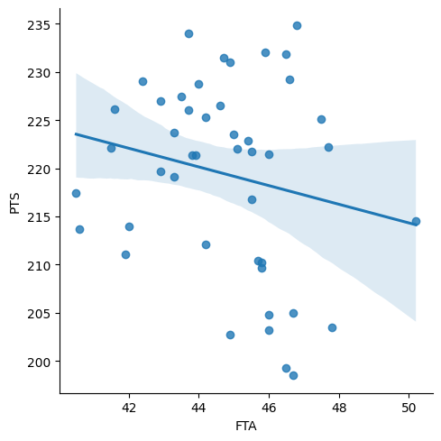

```python
sns.lmplot(x="FTA", y="PTS", data=new_df)
```

Main characteristics I will be analyzing is Free Throw Attempts, the Year, Points, and the Personal Fouls. I want to see how the game is dictated by what the referees call, as that is what is such a controversial topic of discussion among NBA players.

```python
from google.colab import drive
drive.mount('/content/drive')
```

**Primary Analysis and Visualization**

I will be using a regression for my primary analysis because I could visualize somewhat of a linear relationship between the year and the amount of fouls and free throws that were occurring in the previous section. The visuals I provided motivated me to use a linear regression on Free Throw Attempts and Personal Fouls called per game

```python
import pandas as pd
pd.options.mode.chained_assignment = None  # default='warn'
import matplotlib.pyplot as plt
from sklearn import linear_model
from sklearn.model_selection import train_test_split
df = pd.read_csv("Referee_Data.csv")
df2 = df[['Season', 'PF', 'FTA', 'PTS']]
df2['Season']= [x[:4] for x in df2['Season']]
df2['Season'] = [int(x) for x in df2['Season']]
X = df2[['Season']]
Y = df2[['PF']]
X_train, X_test, Y_train, Y_test = train_test_split(X, Y, test_size=0.3)
```

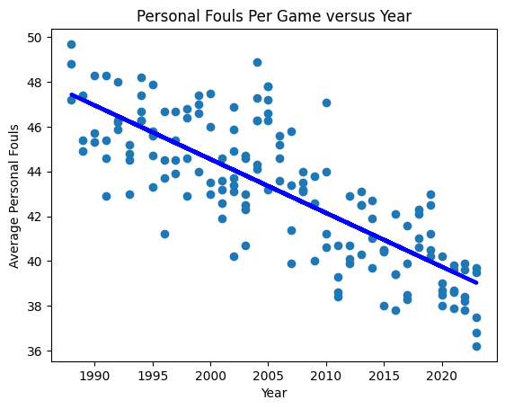

```
Mean squared error: 2.78
R2 Score: 0.70
```

```python
model = linear_model.LinearRegression()
from sklearn.metrics import mean_squared_error, r2_score
model.fit(X_train, Y_train)
Y_pred = model.predict(X_test)
plt.scatter(X, Y)
plt.plot(X_test, Y_pred, color='blue', linewidth=3)
plt.title("Personal Fouls Per Game versus Year")
plt.xlabel("Year")
plt.ylabel("Average Personal Fouls")
plt.show()
print('Mean squared error: %.2f' % mean_squared_error(Y_test, Y_pred))
print('R2 Score: %.2f'% r2_score(Y_test, Y_pred))
```

The R2 score being relatively high means there is some linear correlation between the years and the amount of foul calls. Additionally, the Mean squared error is not too high, especially when understanding how many foul calls are being made every game. The foul calls are overall decreasing as years go by, which is indicated by the line that shows the trend. The data points represent the average personal fouls called during a year by a specific referee. The model is a good fit and supports the hypothesis that foul calls are decreasing and the league has not grown soft. The R2 Score being closer to 1 indicates that the model is a good fit because the test data is being predicted at a high clip

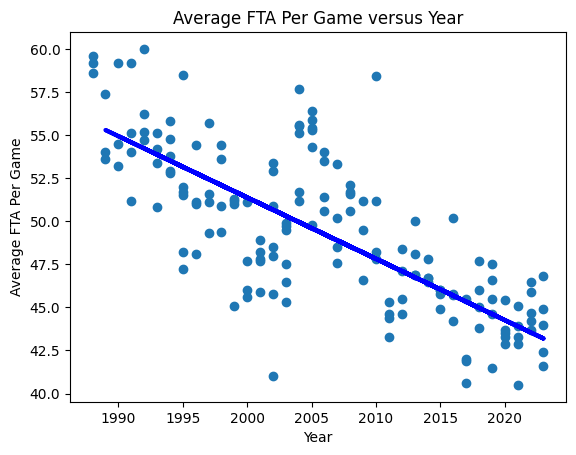

```
Mean squared error: 9.94
R2 Score: 0.48
```

```python
model = linear_model.LinearRegression()
X = df2[['Season']]
Y = df2[['FTA']]
X_train, X_test, Y_train, Y_test = train_test_split(X, Y, test_size=0.3)
model.fit(X_train, Y_train)
Y_pred = model.predict(X_test)
plt.scatter(X, Y)
plt.plot(X_test, Y_pred, color='blue', linewidth=3)
plt.title("Average FTA Per Game versus Year")
plt.ylabel("Average FTA Per Game")
plt.xlabel("Year")
plt.show()
print('Mean squared error: %.2f' % mean_squared_error(Y_test, Y_pred))
print('R2 Score: %.2f'% r2_score(Y_test, Y_pred))
```

During Exploratory Data Analysis, I noticed a significant decrease in the amount of Free Throw Attempts, and it almost appeared Linear. However, the model is not a great fit for the data as the R2 score is relatively low and the MSE is high in comparison to the model that provided a visualization of the average personal fouls per game by the year. In the plot, datapoints represent average FTA for a referee during a specific year. The line plotted shows the general trend, and it is clearly decreasing. Despite the line decreasing, which supports my hypothesis, the model is still not a great fit for the data.

**Insights and Conclusions**

Conclusions that we can draw is that over the years, both foul calls and free throw attempts are decreasing as the years go by. The argument that the game is being made longer by foul calls is not supported by the data or the models because if there are less free throws occurring, then less time is being wasted on foul calls. Additionally, personal fouls are linearly decreasing, which can be visualized by a linear regression.

If I were to conduct further research on the topic, I would compare the length (time) of games as the years go by to see if the games are actually taking too long. I would also take a larger sample size of refs in order to truly grasp the magnitude at which fouls are decreasing.

Walking away from the research that now has been conducted, we can now say that it is unfair to criticize the National Basketball Association and describe the league as "soft" because of an excess of fouls. The fouls are decreasing so an excess does not even exist. A possible reason I propose for why there are so many complaints about the softness of the league is that social media has put a spotlight on every call being made by referees. Referees are on the hot seat every day to perform. Every call they mess up is being recorded and being put on Instagram for everyone, including myself, to see. I often catch myself getting angry at the amount of foul calls. However, the anger is not warranted. Rather than animosity towards the referees, we should just be happy that the referees no longer gamble on games like they used to in the 80s.

```python
%%shell
jupyter nbconvert --to html /content/index.ipynb
```

[output not shown]

[output cut: 133 more lines]

[output not shown]

[output not shown]